# Diamenty

Jagoda Dutkiewicz

6 czerwca 2018

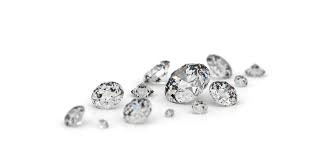

*Ten artykuł dotyczy minerału*.

# Diament

**Diament** bardzo rzadki minerał z gromady pierwiastków rodzimych. Nazwa pochodzi od stgr. *ἀδάμας adamas* (dopełniacz ἀδάμαντος adamantos, łac. diamentum), co znaczy *niepokonany, niezniszczalny* i nawiązuje do wyjątkowej twardości tego minerału. Jest najtwardszą znaną substancją z występujących w przyrodzie.

*Antoine Lavoisier* po raz pierwszy spalił diament pod szklanym kloszem, używając promieni słonecznych skupionych soczewką. Udowodnił w ten sposób, że diament to czysty węgiel.

## Właściwości

- Ma dobrą przewodność cieplną (wynikającą z efektywnego przewodnictwa fononowego): 2000 W/(m·K).
- Jest izolatorem (z wyjątkiem diamentu niebieskiego, będącego półprzewodnikiem).
- Jest trudno topliwy (około 3500 °C) i odporny na działanie kwasów i zasad.
- Może zawierać wrostki innych minerałów.

| właściwości chem. i fiz. | właściwości optyczne |
| --- | --- |
| skład chemiczny | barwa |
| twardość w skali Mosha | rysa |
| przełam | połysk |
| łupliwość | współczynnik załamania |
| układ krystalograficzny | brak |
| gęstość minerału | brak |

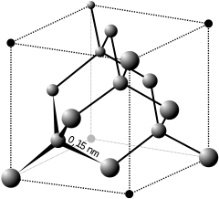

Struktura diamentu

Ze względu na cechy zewnętrzne wyróżnia się kilka typów diamentów:

- **bort** – występuje w postaci nieregularnych zrostów ziarnistych, drobnokrystalicznych skupień -**ballas** – włóknisto-promieniste skupienia kryształów diamentu, występuje zwykle z bortem
- **lonsdaleit** – odmiana diamentu występująca w meteorytach, o sieci regularnej z licznymi defektami
- **karbonado** – zwany też czarnym diamentem, występuje w postaci drobnoziarnistych, porowatych skupień zabarwionych na czarno, szaro lub ciemnozielono, o różnej wielkości (aż do wielkości jaja), przypominających z wyglądu koks (spotykanych przede wszystkim w Bahii w Brazylii)

Diamenty naturalne monokrystaliczne klasyfikuje się na cztery grupy:

1. *Typ Ia* – Stanowi 98% całkowitego wydobycia. Zawiera znaczne ilości azotu (około 1%) stanowiącego zanieczyszczenie. Silnie absorbują ultrafiolet, są optycznie przezroczyste dla fal o długości ponad 320 nm, przewodnictwo cieplne 900 W/(m·K), rezystywność elektryczna >1016 Ω·cm
2. *Typ Ib* – Stanowi 1% całkowitego wydobycia. Zawiera do 0,2% azotu równomiernie rozproszonego w objętości kryształu. Własności optyczne, cieplne i elektryczne jak typ Ia. Do tej grupy należą prawie wszystkie diamenty syntetyczne.
3. *Typ IIa* – Prawie nie zawiera azotu. Rzadko występuje w przyrodzie. Przewodnictwo cieplne 2600 W/(m·K), rezystywność elektryczna >1016 Ω·cm
4. *Typ IIb* – Zawiera domieszkę boru. Błękitna barwa, rezystywność elektryczna >10-1000 Ω·cm, są półprzewodnikami typu p

### Wpływ ilości karatów na cenę diamentów

[figure not shown]

[output not shown]

[output not shown]

#### Bibliografia

Źródło wiadomości: https://pl.wikipedia.org/wiki/Diament